# Introduction to ggplot

Andrew Bell

## *Learning Objectives*

- Review Rzero
- Understand ggplot syntax
- Learn the grammar of graphics
- Start adding to your data visualization toolset

## Review RZero

In essence, most everything you do in R involves **objects**. **Functions** take **arguments** (some of which are objects) and produce outputs (which you can assign to a new object).

Data frames are made up of multiple lists. You can create dataframes using the data_frame() function.

```r
#new object "my_kids" assigned the output of the function "c". The function c creates a list of strings(my_family) or numbers(kid_ages)

my_family <- c("Katie","Finn","Jack","Josie")
kid_ages <- c(NA,1,3,5)
df <- data_frame(my_family, kid_ages)
df
```

| my_family | kid_ages |
| --- | --- |
| Katie | NA |
| Finn | 1 |
| Jack | 3 |
| Josie | 5 |

- **Operators** - can manipulate **objects** (this manipulation can be assigned to a **new object**). To reference specific columns within a dataframe use the `$` symbol (i.e. dataframe`$`columnname).

```r
#new object "how_old_my_kids_will_be_in_5_years" is assigned to the output of kids_ages plus 5

how_old_my_kids_will_be_in_5_years <- df$kid_ages + 5

how_old_my_kids_will_be_in_5_years
```

```
## [1] NA  6  8 10
```

- **Functions** - accept **objects** and returns the result of the function (which can be assigned to a **new object**). NA values can be the bane of any R coder’s existence. Try running the code below without the argument na.rm = TRUE, what does the function return? What do you think na.rm does?

```r
#new object "average_age" is assigned to the output the function mean() which is accepting the kid_ages object

average_age <- mean(kid_ages, na.rm = TRUE)

average_age
```

```
## [1] 3
```

At this point, if you don’t feel comfortable with the differences between objects, functions, arguments, and operators go back to Rzero and work through that lesson again.

## Learning ggplot syntax

We want to be able to make visualizations from data - so we need a function that outputs a plot based on the objects and arguments we give it. Enter the **ggplot()** function. Below is most basic syntax (structure of code required to make the function work) of the ggplot function.

`ggplot(data = <DATA>) + <GEOM_FUNCTION>(mapping = aes(<MAPPINGS>))`

We are going to use the friends_info dataset we used at the end of Rzero to get started with ggplot().

First let’s take a look at our friends_info. Note how many variables and observations are found in the dataset.

```r
friends_info <- read_csv("friends_info.csv")
friends_info
```

| season | episode | title | directed_by | written_by | air_date | us_views_millions | imdb_rating |
| --- | --- | --- | --- | --- | --- | --- | --- |
| 1 | 1 | The Pilot | James Burrows | David Crane & Marta Kauffman | 1994-09-22 | 21.50 | 8.3 |
| 1 | 2 | The One with the Sonogram at the End | James Burrows | David Crane & Marta Kauffman | 1994-09-29 | 20.20 | 8.1 |
| 1 | 3 | The One with the Thumb | James Burrows | Jeffrey Astrof & Mike Sikowitz | 1994-10-06 | 19.50 | 8.2 |
| 1 | 4 | The One with George Stephanopoulos | James Burrows | Alexa Junge | 1994-10-13 | 19.70 | 8.1 |
| 1 | 5 | The One with the East German Laundry Detergent | Pamela Fryman | Jeff Greenstein & Jeff Strauss | 1994-10-20 | 18.60 | 8.5 |
| 1 | 6 | The One with the Butt | Arlene Sanford | Adam Chase & Ira Ungerleider | 1994-10-27 | 18.20 | 8.1 |
| 1 | 7 | The One with the Blackout | James Burrows | Jeffrey Astrof & Mike Sikowitz | 1994-11-03 | 23.50 | 9.0 |
| 1 | 8 | The One Where Nana Dies Twice | James Burrows | Marta Kauffman & David Crane | 1994-11-10 | 21.10 | 8.1 |
| 1 | 9 | The One Where Underdog Gets Away | James Burrows | Jeff Greenstein & Jeff Strauss | 1994-11-17 | 23.10 | 8.2 |
| 1 | 10 | The One with the Monkey | Peter Bonerz | Adam Chase & Ira Ungerleider | 1994-12-15 | 19.90 | 8.1 |

[output cut: 226 more lines]

We want to create an object (first_viz) that contains a visualization created by the ggplot function. The ggplot function takes two essential arguments: data and the mapping of variables to specific aesthetics (like x and y coordinates). For our first visualization, we are going to plot the number of view (US_views_millions) by the critic ratings (imdb_rating)

```r
first_viz <- ggplot(data = friends_info, mapping = aes(x = us_views_millions, y = imdb_rating))
```

Our object now needs a geom layer (think plot type, e.g. scatterplot or bar plot) so we’ll add that layer to our existing first_viz object.

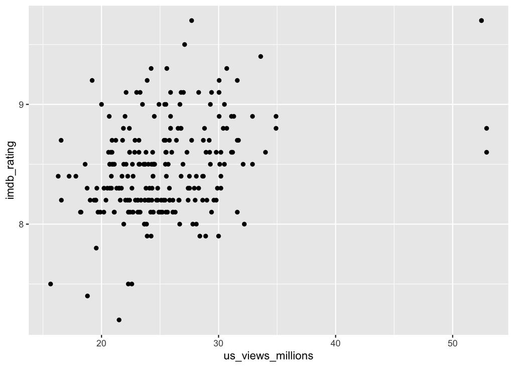

```r
first_viz <- first_viz + geom_point()

first_viz
```

We can continue to add layers to our visualization to do things like format the axis labels, change the axis scales, annotate specific elements of the plot area, etc.

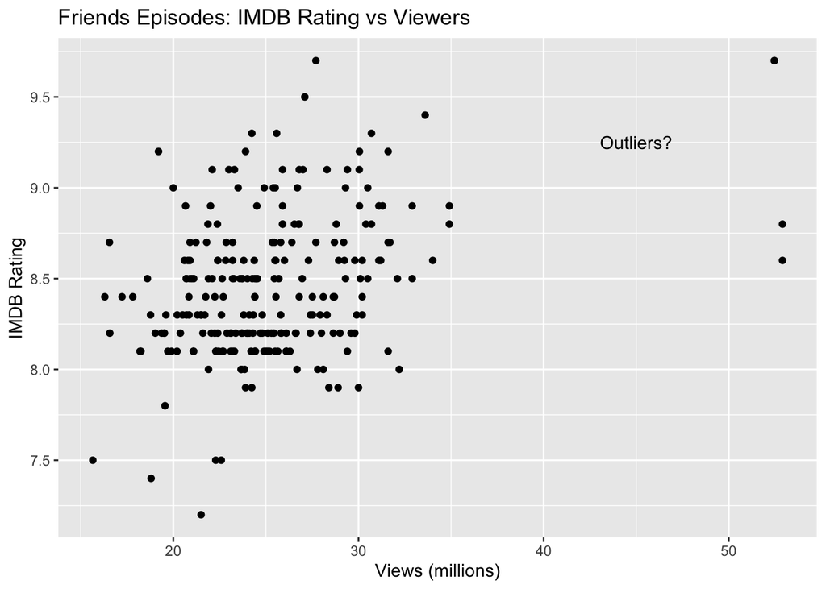

```r
first_viz <- first_viz +
  labs(title = "Friends Episodes: IMDB Rating vs Viewers",
       x = "Views (millions)",
       y = "IMDB Rating")+
  scale_y_continuous(breaks = seq(7,10.5, by = 0.5))+
  annotate("text", x = 45, y = 9.25, label = "Outliers?")

first_viz
```

## Learning all of ggplot’s layers

This simply takes lots of practice. The discoverability of these layers requires knowledge of the options. One the major downsides to R but there are many resources to help.

Resources to help:

- [ggplot cheatsheat](https://github.com/rstudio/cheatsheets/raw/master/data-visualization-2.1.pdf)
- [Esquisser](https://dreamrs.github.io/esquisse/) package as a GUI introduction to the ggplot syntax.

**Esquisse** This is a great tool to get students comfortable with ggplot’s layer / syntax. Workshop to come…

## One more thing… An Introduction to Data Transformation

What if we wanted to learn more about those those outliers that we identified above? We can use some basic data transformation functions to quickly filter our data to learn more abou those specific episodes.

```r
filter_friends <- filter(friends_info, us_views_millions >40)

filter_friends
```

| season | episode | title | directed_by | written_by | air_date | us_views_millions | imdb_rating |
| --- | --- | --- | --- | --- | --- | --- | --- |
| 2 | 12 | The One After the Superbowl | Michael Lembeck | Jeffrey Astrof & Mike SikowitzMichael Borkow | 1996-01-28 | 52.90 | 8.6 |
| 2 | 13 | The One After the Superbowl | Michael Lembeck | Jeffrey Astrof & Mike SikowitzMichael Borkow | 1996-01-28 | 52.90 | 8.8 |
| 10 | 17 | The Last One | Kevin S. Bright | Marta Kauffman & David Crane | 2004-05-06 | 52.46 | 9.7 |
| 10 | 18 | The Last One | Kevin S. Bright | Marta Kauffman & David Crane | 2004-05-06 | 52.46 | 9.7 |

This brings up another issue: some ‘titles’ are made up of two episodes and when points overlap on our visualization, we can’t see them. How could we fix this?

```r
title_friends <- friends_info %>%
  group_by(title)%>%
  summarise(mean_views = mean(us_views_millions),
            mean_rating = mean(imdb_rating))

title_friends
```

| title | mean_views | mean_rating |
| --- | --- | --- |
| The Last One | 52.46 | 9.70 |
| The One After 'I Do' | 31.70 | 8.70 |
| The One After Joey and Rachel Kiss | 24.54 | 8.50 |
| The One After Ross Says Rachel | 31.10 | 8.90 |
| The One After the Superbowl | 52.90 | 8.70 |
| The One After Vegas | 27.70 | 8.70 |
| The One at the Beach | 28.80 | 8.80 |
| The One Hundredth | 26.80 | 8.80 |
| The One in Barbados | 25.46 | 8.60 |
| The One in Massapequa | 22.05 | 8.20 |

[output cut: 217 more lines]

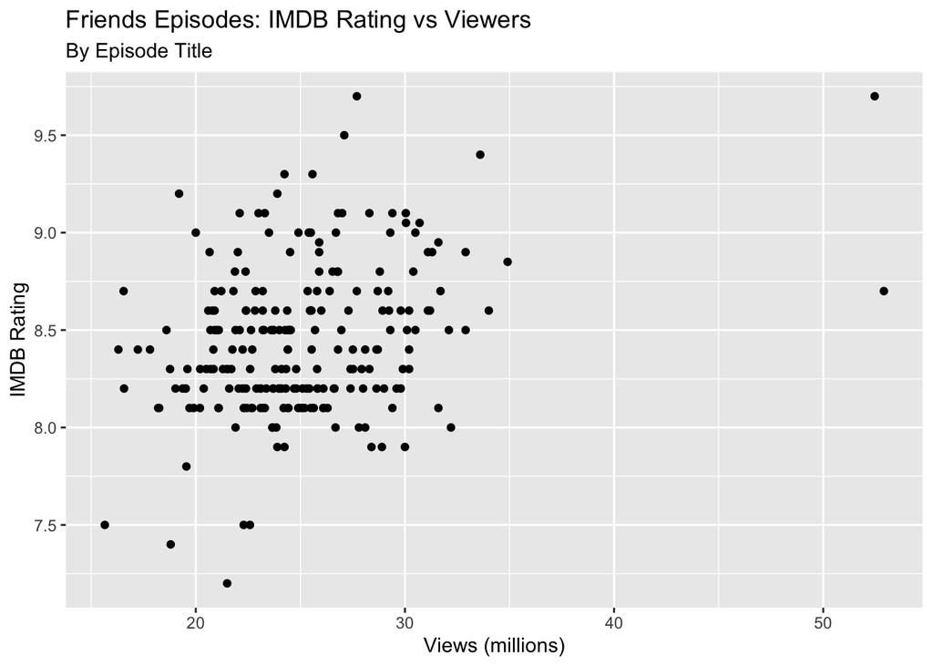

```r
second_viz <- ggplot(data = title_friends, mapping = aes(x = mean_views, y = mean_rating))+
  geom_point()+
  #geom_jitter()+
  labs(title = "Friends Episodes: IMDB Rating vs Viewers",
       subtitle = "By Episode Title",
       x = "Views (millions)",
       y = "IMDB Rating")+
  scale_y_continuous(breaks = seq(7,10.5, by = 0.5))

second_viz
```

Suppose we want to look at the mean IMDB rating by season. What kind of data transformations and/or geom_layer might we need to run on the data?

```r
#option number 1 - generate the mean rating using dplyr functions and plot resulting values in bar plot
IMDB_byseason <- friends_info%>%
  group_by(season)%>%
  summarise(mean_IMDB = mean(imdb_rating))

IMDB_byseason
```

| season | mean_IMDB |
| --- | --- |
| 1 | 8.316667 |
| 2 | 8.458333 |
| 3 | 8.408000 |
| 4 | 8.475000 |
| 5 | 8.637500 |
| 6 | 8.496000 |
| 7 | 8.437500 |
| 8 | 8.450000 |
| 9 | 8.304167 |
| 10 | 8.688889 |

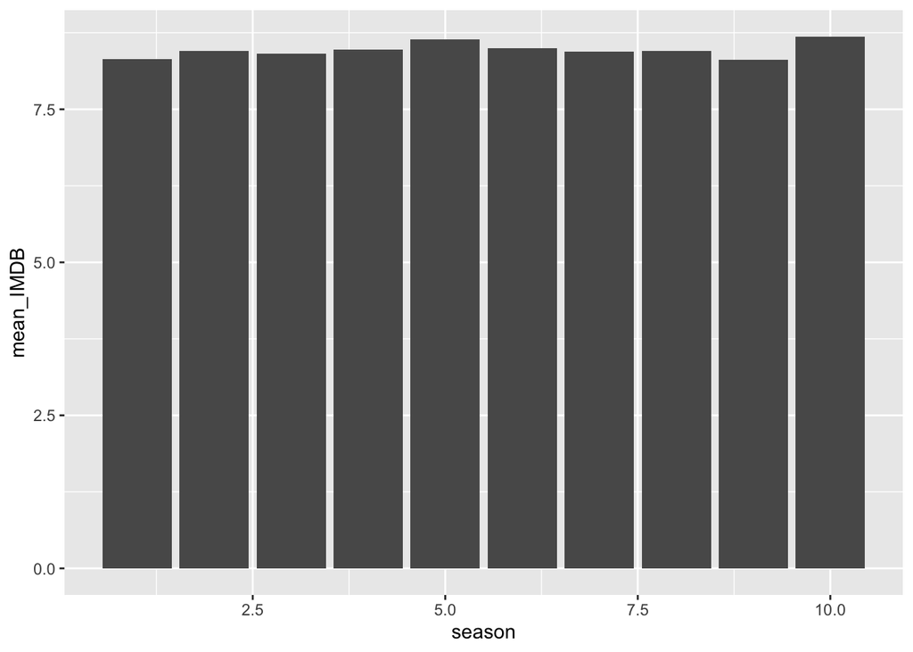

```r
ggplot(IMDB_byseason, aes(season, mean_IMDB))+
  geom_bar(stat = "identity")
```

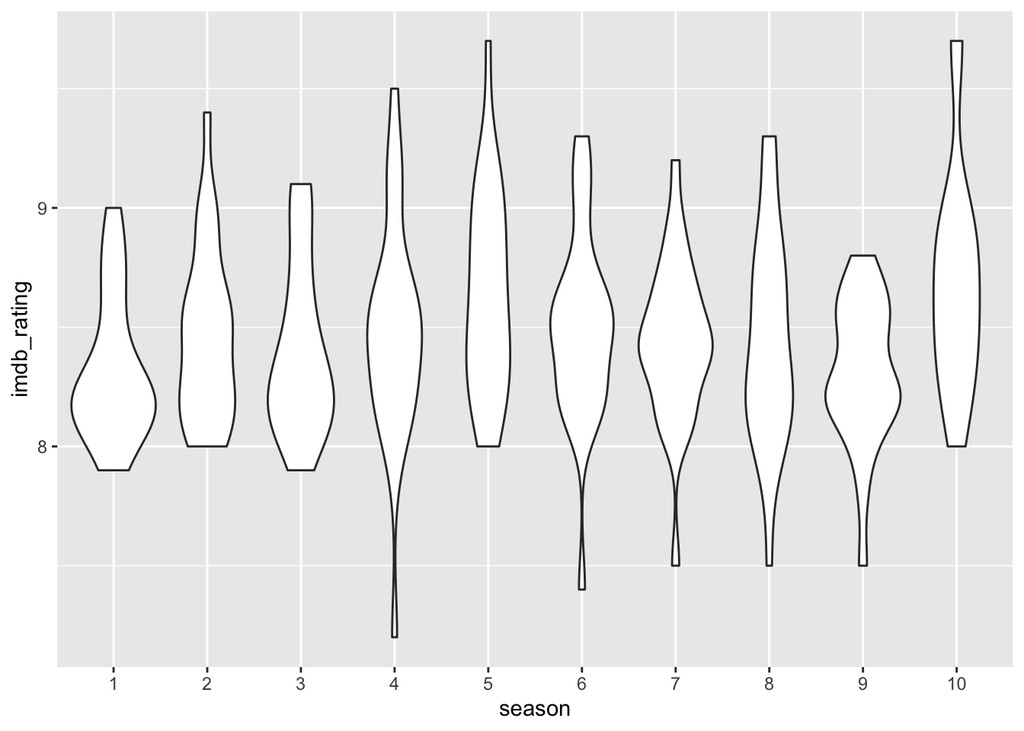

```r
#option number 2 - generate a boxplot or violin plot to look at the distribution of the ratings by season without having to specific run any data transformations.

friends_info$season <- as.factor(friends_info$season)
ggplot(friends_info, aes(season, imdb_rating))+
  #geom_boxplot()+
  geom_violin()
```